# Exercício de Análise Fatorial: Saúde Mental e Qualidade de Vida

Ricardo Limongi

2025-03-18

# 1 Introdução

Este exercício demonstra a aplicação da Análise Fatorial em dados de saúde mental e qualidade de vida. Utilizaremos um conjunto de dados simulados baseado no questionário WHOQOL-BREF, um instrumento da Organização Mundial da Saúde (OMS) para avaliar a qualidade de vida.

## 1.1 Objetivo do Exercício

1. Realizar uma Análise Fatorial Exploratória (AFE) para examinar a estrutura subjacente do questionário
2. Confirmar a estrutura fatorial através de Análise Fatorial Confirmatória (AFC)
3. Interpretar os resultados em contexto de saúde
4. Avaliar a adequação do modelo e possíveis melhorias

# 2 Simulação dos Dados

```r
# Configurar uma semente para reproduzibilidade
set.seed(12345)

# Número de observações
n <- 500

# Simular dados baseados na estrutura teórica do WHOQOL-BREF
# O WHOQOL-BREF possui 4 domínios:
# 1. Físico (7 itens)
# 2. Psicológico (6 itens)
# 3. Relações Sociais (3 itens)
# 4. Meio Ambiente (8 itens)
# Mais 2 itens gerais

# Criar matriz de correlação para cada domínio
criar_itens_correlacionados <- function(n, n_itens, correlacao_media, sd_item = 1) {
  # Correlação entre itens dentro do mesmo fator
  sigma <- matrix(correlacao_media, n_itens, n_itens)
  diag(sigma) <- 1

  # Criar dados correlacionados
  dados <- MASS::mvrnorm(n, mu = rep(0, n_itens), Sigma = sigma)

  # Transformar para escala Likert (1-5)
  dados <- scale(dados)  # Padronizar
  dados <- dados * sd_item + 3  # média 3, desvio padrão ajustável
  dados <- pmin(pmax(round(dados), 1), 5)  # Arredondar e limitar entre 1 e 5

  return(dados)
}

# Simulando os 4 domínios
fisico <- criar_itens_correlacionados(n, 7, 0.6, 1.2)
psicologico <- criar_itens_correlacionados(n, 6, 0.55, 1.1)
social <- criar_itens_correlacionados(n, 3, 0.65, 1)
ambiente <- criar_itens_correlacionados(n, 8, 0.5, 0.9)
geral <- criar_itens_correlacionados(n, 2, 0.7, 1.3)

# Adicionar ruído e correlações cruzadas menores entre os domínios
adicionar_correlacoes_cruzadas <- function(dominio1, dominio2, forca = 0.2) {
  n <- nrow(dominio1)
  k1 <- ncol(dominio1)
  k2 <- ncol(dominio2)

  ruido <- matrix(rnorm(n * k1, 0, 0.5), n, k1)
  influencia <- dominio2[, sample(1:k2, 1)] * forca

  resultado <- dominio1 + ruido + influencia
  resultado <- pmin(pmax(round(resultado), 1), 5)  # Restringir a 1-5

  return(resultado)
}

# Adicionar correlações cruzadas
fisico <- adicionar_correlacoes_cruzadas(fisico, psicologico, 0.15)
psicologico <- adicionar_correlacoes_cruzadas(psicologico, fisico, 0.15)
social <- adicionar_correlacoes_cruzadas(social, psicologico, 0.2)
ambiente <- adicionar_correlacoes_cruzadas(ambiente, fisico, 0.1)

# Juntar os dados e nomear as colunas
dados_whoqol <- data.frame(
  Q1 = geral[,1],
  Q2 = geral[,2],
  Q3 = fisico[,1],
  Q4 = fisico[,2],
  Q5 = psicologico[,1],
  Q6 = psicologico[,2],
  Q7 = psicologico[,3],
  Q8 = ambiente[,1],
  Q9 = ambiente[,2],
  Q10 = fisico[,3],
  Q11 = psicologico[,4],
  Q12 = ambiente[,3],
  Q13 = ambiente[,4],
  Q14 = ambiente[,5],
  Q15 = fisico[,4],
  Q16 = fisico[,5],
  Q17 = fisico[,6],
  Q18 = fisico[,7],
  Q19 = psicologico[,5],
  Q20 = social[,1],
  Q21 = social[,2],
  Q22 = social[,3],
  Q23 = ambiente[,6],
  Q24 = ambiente[,7],
  Q25 = ambiente[,8],
  Q26 = psicologico[,6]
)

# Visualizar estrutura dos dados
glimpse(dados_whoqol)
```

```
## Rows: 500
## Columns: 26
## $ Q1  <dbl> 4, 2, 2, 2, 1, 2, 2, 3, 3, 4, 3, 2, 2, 5, 4, 1, 3, 4, 3, 3, 3, 4, …
## $ Q2  <dbl> 4, 1, 1, 3, 3, 2, 1, 3, 3, 3, 2, 3, 2, 5, 4, 2, 4, 4, 4, 4, 4, 4, …
## $ Q3  <dbl> 3, 1, 5, 4, 3, 3, 2, 5, 3, 5, 4, 2, 5, 3, 4, 3, 5, 3, 1, 4, 3, 2, …
## $ Q4  <dbl> 3, 3, 4, 5, 3, 5, 2, 4, 5, 4, 4, 1, 3, 3, 4, 2, 5, 4, 5, 3, 4, 1, …
## $ Q5  <dbl> 4, 4, 3, 4, 3, 2, 5, 4, 3, 4, 4, 5, 4, 4, 3, 3, 2, 4, 3, 4, 2, 3, …
## $ Q6  <dbl> 3, 5, 3, 2, 2, 4, 5, 4, 4, 4, 3, 3, 4, 4, 2, 2, 2, 3, 2, 4, 1, 3, …
## $ Q7  <dbl> 3, 4, 4, 3, 3, 4, 5, 4, 5, 4, 4, 4, 5, 2, 1, 3, 3, 4, 1, 2, 2, 5, …
## $ Q8  <dbl> 4, 4, 3, 3, 2, 4, 4, 4, 4, 4, 4, 3, 3, 2, 4, 3, 4, 5, 3, 3, 3, 5, …
## $ Q9  <dbl> 5, 4, 3, 4, 2, 4, 4, 4, 4, 3, 4, 3, 2, 3, 4, 4, 5, 3, 4, 5, 2, 5, …
## $ Q10 <dbl> 5, 3, 3, 4, 1, 5, 2, 3, 5, 4, 4, 3, 3, 4, 4, 2, 4, 5, 2, 4, 3, 2, …
## $ Q11 <dbl> 4, 5, 4, 1, 3, 5, 5, 5, 2, 5, 3, 5, 5, 2, 2, 3, 5, 5, 1, 5, 4, 3, …
## $ Q12 <dbl> 3, 3, 2, 5, 2, 5, 4, 5, 2, 5, 3, 2, 5, 4, 4, 5, 5, 4, 5, 3, 3, 5, …
## $ Q13 <dbl> 4, 5, 2, 5, 2, 4, 3, 5, 2, 5, 4, 1, 3, 4, 3, 3, 4, 5, 2, 2, 3, 3, …
## $ Q14 <dbl> 5, 5, 3, 5, 4, 5, 3, 5, 1, 3, 5, 2, 2, 3, 3, 3, 5, 3, 2, 3, 3, 2, …
## $ Q15 <dbl> 2, 3, 4, 4, 2, 5, 4, 4, 3, 5, 3, 1, 4, 1, 4, 2, 4, 3, 1, 4, 3, 3, …
## $ Q16 <dbl> 2, 2, 4, 5, 3, 5, 4, 4, 2, 5, 4, 1, 4, 3, 4, 4, 4, 4, 2, 2, 3, 2, …
## $ Q17 <dbl> 4, 3, 3, 4, 3, 5, 5, 3, 3, 4, 3, 1, 3, 2, 4, 5, 5, 2, 4, 3, 2, 3, …
## $ Q18 <dbl> 3, 2, 3, 2, 4, 5, 2, 4, 5, 5, 2, 2, 2, 2, 5, 3, 4, 3, 2, 2, 3, 1, …
## $ Q19 <dbl> 5, 2, 4, 2, 4, 4, 5, 4, 3, 4, 3, 4, 5, 3, 4, 4, 3, 4, 2, 3, 3, 1, …
## $ Q20 <dbl> 3, 5, 4, 4, 2, 5, 3, 3, 5, 3, 5, 4, 5, 5, 3, 5, 5, 5, 4, 3, 5, 5, …
## $ Q21 <dbl> 5, 5, 3, 3, 3, 5, 3, 5, 5, 2, 5, 5, 5, 5, 3, 5, 4, 5, 2, 5, 3, 3, …
## $ Q22 <dbl> 5, 4, 3, 3, 2, 5, 2, 5, 5, 3, 4, 4, 5, 5, 2, 5, 5, 5, 4, 3, 5, 3, …
## $ Q23 <dbl> 5, 4, 4, 5, 2, 5, 5, 4, 2, 5, 4, 2, 4, 1, 3, 4, 4, 5, 4, 3, 5, 4, …
## $ Q24 <dbl> 5, 5, 2, 5, 3, 5, 4, 4, 2, 3, 4, 2, 4, 2, 3, 3, 4, 5, 3, 4, 4, 3, …
## $ Q25 <dbl> 5, 5, 3, 5, 2, 5, 3, 5, 4, 3, 4, 1, 4, 2, 3, 2, 4, 4, 4, 4, 2, 3, …
## $ Q26 <dbl> 4, 2, 4, 1, 3, 5, 4, 4, 3, 4, 3, 5, 4, 3, 4, 2, 3, 4, 2, 4, 2, 2, …
```

```r
# Resumo dos dados
summary(dados_whoqol)
```

```
##        Q1              Q2              Q3              Q4
##  Min.   :1.000   Min.   :1.000   Min.   :1.000   Min.   :1.000
##  1st Qu.:2.000   1st Qu.:2.000   1st Qu.:3.000   1st Qu.:3.000
##  Median :3.000   Median :3.000   Median :3.000   Median :3.000
##  Mean   :2.974   Mean   :3.014   Mean   :3.414   Mean   :3.394
##  3rd Qu.:4.000   3rd Qu.:4.000   3rd Qu.:4.000   3rd Qu.:4.000
##  Max.   :5.000   Max.   :5.000   Max.   :5.000   Max.   :5.000
##        Q5              Q6              Q7              Q8
##  Min.   :1.000   Min.   :1.000   Min.   :1.000   Min.   :1.000
##  1st Qu.:3.000   1st Qu.:3.000   1st Qu.:3.000   1st Qu.:3.000
##  Median :4.000   Median :4.000   Median :3.000   Median :3.000
##  Mean   :3.446   Mean   :3.458   Mean   :3.438   Mean   :3.332
##  3rd Qu.:4.000   3rd Qu.:4.000   3rd Qu.:4.000   3rd Qu.:4.000
##  Max.   :5.000   Max.   :5.000   Max.   :5.000   Max.   :5.000
##        Q9             Q10             Q11             Q12
##  Min.   :1.000   Min.   :1.000   Min.   :1.000   Min.   :1.000
##  1st Qu.:3.000   1st Qu.:3.000   1st Qu.:3.000   1st Qu.:3.000
##  Median :3.000   Median :3.000   Median :4.000   Median :3.000
##  Mean   :3.282   Mean   :3.376   Mean   :3.452   Mean   :3.326
##  3rd Qu.:4.000   3rd Qu.:4.000   3rd Qu.:4.000   3rd Qu.:4.000
##  Max.   :5.000   Max.   :5.000   Max.   :5.000   Max.   :5.000
##       Q13             Q14            Q15             Q16            Q17
##  Min.   :1.000   Min.   :1.00   Min.   :1.000   Min.   :1.00   Min.   :1.000
##  1st Qu.:3.000   1st Qu.:3.00   1st Qu.:3.000   1st Qu.:3.00   1st Qu.:3.000
##  Median :3.000   Median :3.00   Median :3.000   Median :3.00   Median :3.000
##  Mean   :3.296   Mean   :3.31   Mean   :3.396   Mean   :3.42   Mean   :3.368
##  3rd Qu.:4.000   3rd Qu.:4.00   3rd Qu.:4.000   3rd Qu.:4.00   3rd Qu.:4.000
##  Max.   :5.000   Max.   :5.00   Max.   :5.000   Max.   :5.00   Max.   :5.000
##       Q18             Q19             Q20            Q21             Q22
##  Min.   :1.000   Min.   :1.000   Min.   :1.00   Min.   :1.000   Min.   :1.000
##  1st Qu.:3.000   1st Qu.:3.000   1st Qu.:3.00   1st Qu.:3.000   1st Qu.:3.000
##  Median :3.000   Median :4.000   Median :4.00   Median :4.000   Median :4.000
##  Mean   :3.378   Mean   :3.436   Mean   :3.66   Mean   :3.628   Mean   :3.624
##  3rd Qu.:4.000   3rd Qu.:4.000   3rd Qu.:5.00   3rd Qu.:5.000   3rd Qu.:5.000
##  Max.   :5.000   Max.   :5.000   Max.   :5.00   Max.   :5.000   Max.   :5.000
##       Q23           Q24             Q25             Q26
##  Min.   :1.0   Min.   :1.000   Min.   :1.000   Min.   :1.000
##  1st Qu.:3.0   1st Qu.:3.000   1st Qu.:3.000   1st Qu.:3.000
##  Median :3.0   Median :3.000   Median :3.000   Median :3.000
##  Mean   :3.3   Mean   :3.334   Mean   :3.344   Mean   :3.408
##  3rd Qu.:4.0   3rd Qu.:4.000   3rd Qu.:4.000   3rd Qu.:4.000
##  Max.   :5.0   Max.   :5.000   Max.   :5.000   Max.   :5.000
```

## 2.1 Pré-processamento dos Dados

```r
# Selecionando apenas as questões (do Q1 a Q26)
questoes <- dados_whoqol

# Verificar valores ausentes
sum(is.na(questoes))
```

```
## [1] 0
```

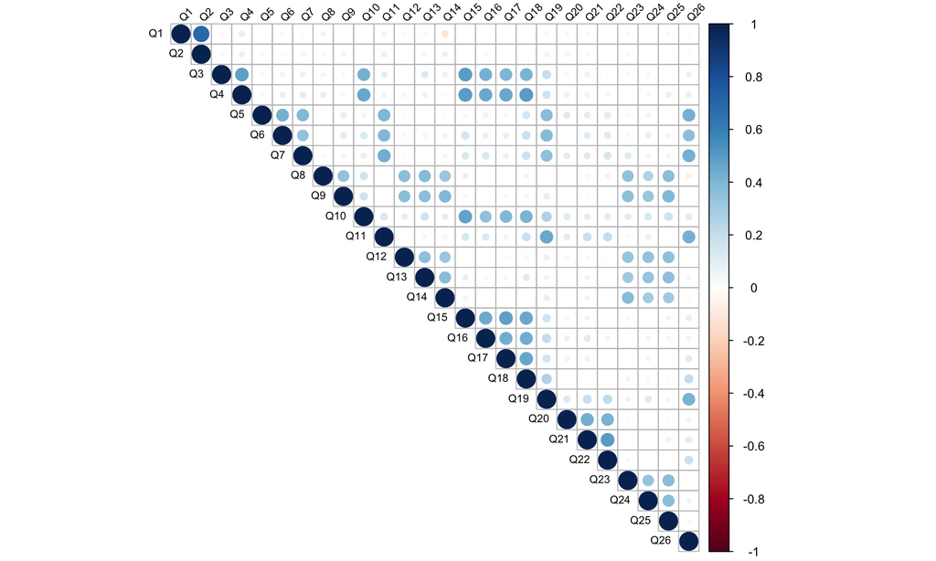

```r
# Verificar as correlações entre as variáveis
corrplot(cor(questoes), method = "circle", type = "upper",
         tl.col = "black", tl.cex = 0.7, tl.srt = 45)
```

# 3 Análise Fatorial Exploratória (AFE)

## 3.1 Verificação de Adequação dos Dados

```r
# Teste de Kaiser-Meyer-Olkin (KMO)
# Valores acima de 0.6 são considerados adequados
KMO(questoes)
```

```
## Kaiser-Meyer-Olkin factor adequacy
## Call: KMO(r = questoes)
## Overall MSA =  0.84
## MSA for each item =
##   Q1   Q2   Q3   Q4   Q5   Q6   Q7   Q8   Q9  Q10  Q11  Q12  Q13  Q14  Q15  Q16
## 0.50 0.51 0.90 0.89 0.84 0.86 0.84 0.87 0.87 0.90 0.87 0.87 0.87 0.87 0.88 0.90
##  Q17  Q18  Q19  Q20  Q21  Q22  Q23  Q24  Q25  Q26
## 0.89 0.89 0.89 0.70 0.71 0.72 0.87 0.88 0.87 0.85
```

```r
# Teste de esfericidade de Bartlett
# Deve ser significativo (p < 0.05)
cortest.bartlett(cor(questoes), n = nrow(questoes))
```

```
## $chisq
## [1] 3675.145
##
## $p.value
## [1] 0
##
## $df
## [1] 325
```

## 3.2 Determinação do Número de Fatores

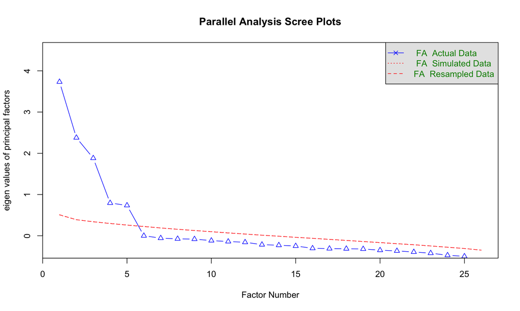

```
## Parallel analysis suggests that the number of factors =  5  and the number of components =  NA
```

```r
# Análise paralela para determinar o número de fatores
fa.parallel(questoes, fa = "fa", n.iter = 100)
```

## 3.3 Execução da Análise Fatorial Exploratória

```r
# Com base na análise paralela, execute a AFE com o número sugerido de fatores
# Vamos supor que foram sugeridos 4 fatores (baseado na estrutura simulada)
num_fatores <- 4  # Ajuste conforme resultado da análise paralela

# Execução da AFE com rotação varimax
afe_result <- fa(questoes,
                 nfactors = num_fatores,
                 rotate = "varimax",
                 fm = "ml")

# Exibir cargas fatoriais (apenas as maiores que 0.3)
print(afe_result$loadings, cutoff = 0.3)
```

```
##
## Loadings:
##     ML2    ML3    ML4    ML1
## Q1                        0.997
## Q2                        0.701
## Q3   0.659
## Q4   0.712
## Q5                 0.626
## Q6                 0.575
## Q7                 0.609
## Q8          0.584
## Q9          0.624
## Q10  0.611
## Q11                0.678
## Q12         0.593
## Q13         0.597
## Q14         0.575
## Q15  0.708
## Q16  0.623
## Q17  0.657
## Q18  0.648
## Q19                0.623
## Q20
## Q21
## Q22
## Q23         0.581
## Q24         0.537
## Q25         0.618
## Q26                0.646
##
##                  ML2   ML3   ML4   ML1
## SS loadings    3.140 2.841 2.660 1.521
## Proportion Var 0.121 0.109 0.102 0.059
## Cumulative Var 0.121 0.230 0.332 0.391
```

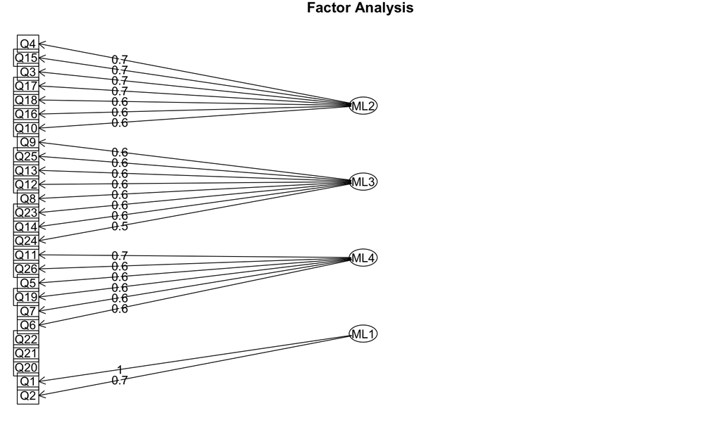

```r
# Visualização das cargas fatoriais
fa.diagram(afe_result)
```

```r
# Estatísticas por fator
afe_result
```

```
## Factor Analysis using method =  ml
## Call: fa(r = questoes, nfactors = num_fatores, rotate = "varimax",
##     fm = "ml")
## Standardized loadings (pattern matrix) based upon correlation matrix
##       ML2   ML3   ML4   ML1    h2     u2 com
## Q1   0.03  0.00 -0.01  1.00 0.994 0.0059 1.0
## Q2   0.02 -0.04 -0.05  0.70 0.495 0.5054 1.0
## Q3   0.66  0.03  0.06  0.01 0.438 0.5616 1.0
## Q4   0.71  0.04  0.05  0.06 0.516 0.4842 1.0
## Q5  -0.01  0.02  0.63 -0.01 0.393 0.6072 1.0
## Q6   0.08  0.06  0.57  0.04 0.341 0.6589 1.1
## Q7   0.07  0.03  0.61  0.02 0.378 0.6225 1.0
## Q8   0.06  0.58 -0.04  0.05 0.350 0.6502 1.1
## Q9   0.03  0.62  0.06  0.01 0.395 0.6053 1.0
## Q10  0.61  0.20  0.13  0.00 0.429 0.5715 1.3
## Q11  0.07 -0.01  0.68 -0.06 0.469 0.5307 1.0
## Q12 -0.01  0.59  0.01  0.03 0.352 0.6479 1.0
## Q13  0.10  0.60 -0.02 -0.04 0.369 0.6310 1.1
## Q14  0.02  0.58  0.04 -0.12 0.346 0.6537 1.1
## Q15  0.71  0.03  0.09 -0.01 0.512 0.4882 1.0
## Q16  0.62  0.00  0.11 -0.01 0.400 0.6004 1.1
## Q17  0.66 -0.01  0.06  0.00 0.436 0.5645 1.0
## Q18  0.65  0.00  0.21 -0.01 0.464 0.5361 1.2
## Q19  0.20  0.08  0.62 -0.05 0.437 0.5629 1.3
## Q20  0.06  0.01  0.18 -0.04 0.037 0.9626 1.3
## Q21  0.06  0.06  0.26  0.03 0.073 0.9273 1.2
## Q22  0.02  0.00  0.30  0.00 0.089 0.9107 1.0
## Q23  0.00  0.58  0.06 -0.03 0.342 0.6581 1.0
## Q24  0.03  0.54  0.09  0.01 0.298 0.7020 1.1
## Q25  0.03  0.62  0.02  0.04 0.385 0.6151 1.0
## Q26  0.06 -0.07  0.65 -0.02 0.426 0.5743 1.0
##
##                        ML2  ML3  ML4  ML1
## SS loadings           3.14 2.84 2.66 1.52
## Proportion Var        0.12 0.11 0.10 0.06
## Cumulative Var        0.12 0.23 0.33 0.39
## Proportion Explained  0.31 0.28 0.26 0.15
## Cumulative Proportion 0.31 0.59 0.85 1.00
##
## Mean item complexity =  1.1
## Test of the hypothesis that 4 factors are sufficient.
##
## df null model =  325  with the objective function =  7.51 with Chi Square =  3675.15
## df of  the model are 227  and the objective function was  0.91
##
## The root mean square of the residuals (RMSR) is  0.04
## The df corrected root mean square of the residuals is  0.05
##
## The harmonic n.obs is  500 with the empirical chi square  642.99  with prob <  2e-41
## The total n.obs was  500  with Likelihood Chi Square =  445.02  with prob <  2.6e-16
##
## Tucker Lewis Index of factoring reliability =  0.906
## RMSEA index =  0.044  and the 90 % confidence intervals are  0.038 0.05
## BIC =  -965.7
## Fit based upon off diagonal values = 0.95
## Measures of factor score adequacy
##                                                    ML2  ML3  ML4  ML1
## Correlation of (regression) scores with factors   0.92 0.90 0.90 1.00
## Multiple R square of scores with factors          0.84 0.81 0.80 0.99
## Minimum correlation of possible factor scores     0.69 0.63 0.61 0.99
```

## 3.4 Interpretação dos Fatores

```r
# Calcular a variância explicada por cada fator
sum(afe_result$values) # Variância total
```

```
## [1] 10.16194
```

```r
afe_result$values # Eigenvalues
```

```
##  [1]  3.91131248  2.66330614  2.10119771  1.49717197  0.84673699  0.16401078
##  [7]  0.16338806  0.12622244  0.10874925  0.10000930  0.06740378  0.05135436
## [13]  0.03979257  0.01925480  0.01221435 -0.03846324 -0.05168156 -0.06503463
## [19] -0.09082756 -0.09991157 -0.10462403 -0.11866065 -0.13024397 -0.18388944
## [25] -0.38914961 -0.43769808
```

```r
afe_result$Vaccounted # Proporção da variância explicada
```

```
##                             ML2       ML3       ML4        ML1
## SS loadings           3.1398397 2.8406527 2.6602123 1.52123598
## Proportion Var        0.1207631 0.1092559 0.1023159 0.05850908
## Cumulative Var        0.1207631 0.2300189 0.3323348 0.39084387
## Proportion Explained  0.3089803 0.2795384 0.2617819 0.14969936
## Cumulative Proportion 0.3089803 0.5885187 0.8503006 1.00000000
```

```r
# Visualizar as comunalidades (proporção da variância explicada pelos fatores para cada variável)
afe_result$communality
```

```
##         Q1         Q2         Q3         Q4         Q5         Q6         Q7
## 0.99412922 0.49456080 0.43839510 0.51582383 0.39283832 0.34111041 0.37753033
##         Q8         Q9        Q10        Q11        Q12        Q13        Q14
## 0.34983124 0.39465114 0.42853361 0.46926269 0.35209589 0.36901929 0.34625267
##        Q15        Q16        Q17        Q18        Q19        Q20        Q21
## 0.51182691 0.39962045 0.43551961 0.46394746 0.43707647 0.03744813 0.07271789
##        Q22        Q23        Q24        Q25        Q26
## 0.08926158 0.34191777 0.29800081 0.38489381 0.42567519
```

# 4 Análise Fatorial Confirmatória (AFC)

## 4.1 Definição do Modelo

```r
# Criação do modelo AFC com base nos resultados da AFE
# Nota: Este modelo deve ser ajustado conforme os resultados da AFE
modelo_afc <- '
  # Definição dos fatores baseados na estrutura teórica do WHOQOL-BREF
  FisicoSaude =~ Q3 + Q4 + Q10 + Q15 + Q16 + Q17 + Q18
  Psicologico =~ Q5 + Q6 + Q7 + Q11 + Q19 + Q26
  RelacoeSociais =~ Q20 + Q21 + Q22
  MeioAmbiente =~ Q8 + Q9 + Q12 + Q13 + Q14 + Q23 + Q24 + Q25
  QualidadeGeral =~ Q1 + Q2
'
```

## 4.2 Execução da AFC

```r
# Ajustar o modelo AFC
afc_result <- cfa(modelo_afc, data = questoes)

# Resumo dos resultados com medidas de ajuste
summary(afc_result, fit.measures = TRUE, standardized = TRUE)
```

```
## lavaan 0.6-19 ended normally after 70 iterations
##
##   Estimator                                         ML
##   Optimization method                           NLMINB
##   Number of model parameters                        62
##
##   Number of observations                           500
##
## Model Test User Model:
##
##   Test statistic                               325.410
##   Degrees of freedom                               289
##   P-value (Chi-square)                           0.069
##
## Model Test Baseline Model:
##
##   Test statistic                              3753.979
##   Degrees of freedom                               325
##   P-value                                        0.000
##
## User Model versus Baseline Model:
##
##   Comparative Fit Index (CFI)                    0.989
##   Tucker-Lewis Index (TLI)                       0.988
##
## Loglikelihood and Information Criteria:
##
##   Loglikelihood user model (H0)             -18278.518
##   Loglikelihood unrestricted model (H1)     -18115.813
##
##   Akaike (AIC)                               36681.037
##   Bayesian (BIC)                             36942.343
##   Sample-size adjusted Bayesian (SABIC)      36745.551
##
## Root Mean Square Error of Approximation:
##
##   RMSEA                                          0.016
##   90 Percent confidence interval - lower         0.000
##   90 Percent confidence interval - upper         0.024
##   P-value H_0: RMSEA <= 0.050                    1.000
```

[output cut: 81 more lines]

```
##    .Q8                0.720    0.052   13.952    0.000    0.720    0.665
##    .Q9                0.670    0.050   13.447    0.000    0.670    0.610
##    .Q12               0.750    0.054   13.827    0.000    0.750    0.651
##    .Q13               0.739    0.054   13.724    0.000    0.739    0.639
##    .Q14               0.759    0.054   13.964    0.000    0.759    0.667
##    .Q23               0.760    0.055   13.876    0.000    0.760    0.656
##    .Q24               0.764    0.054   14.255    0.000    0.764    0.703
##    .Q25               0.737    0.054   13.555    0.000    0.737    0.621
##    .Q1                0.974    0.456    2.135    0.033    0.974    0.638
##    .Q2               -0.502    1.582   -0.317    0.751   -0.502   -0.351
##     FisicoSaude       0.604    0.078    7.714    0.000    1.000    1.000
##     Psicologico       0.509    0.073    6.968    0.000    1.000    1.000
##     RelacoeSociais    0.431    0.071    6.035    0.000    1.000    1.000
##     MeioAmbiente      0.362    0.057    6.403    0.000    1.000    1.000
##     QualidadeGeral    0.552    0.458    1.205    0.228    1.000    1.000
```

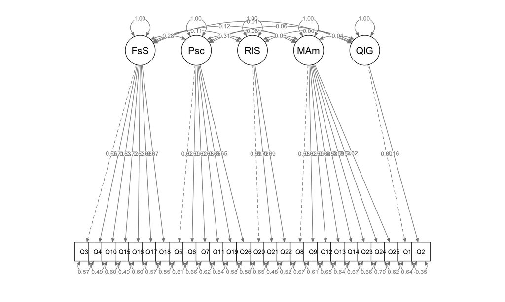

```r
# Visualização do modelo
semPaths(afc_result, whatLabels = "std", layout = "tree",
         edge.label.cex = 0.7, normalize = FALSE)
```

## 4.3 Verificação do Ajuste do Modelo

```r
# Medidas de ajuste
fitMeasures(afc_result, c("chisq", "df", "pvalue", "cfi", "tli", "rmsea", "srmr"))
```

```
##   chisq      df  pvalue     cfi     tli   rmsea    srmr
## 325.410 289.000   0.069   0.989   0.988   0.016   0.040
```

```r
# Índices de modificação para possíveis melhorias no modelo
mi <- modificationindices(afc_result)
head(mi[order(mi$mi, decreasing = TRUE), ], 10)
```

```
##              lhs op rhs     mi    epc sepc.lv sepc.all sepc.nox
## 132 MeioAmbiente =~ Q10 18.957  0.355   0.213    0.180    0.180
## 72   FisicoSaude =~ Q19 13.982  0.243   0.189    0.161    0.161
## 93   Psicologico =~ Q18 11.943  0.240   0.171    0.145    0.145
## 485          Q14 ~~  Q1  9.591 -0.112  -0.112   -0.131   -0.131
## 229          Q10 ~~ Q19  9.042  0.125   0.125    0.152    0.152
## 372           Q7 ~~ Q23  6.260  0.096   0.096    0.126    0.126
## 142 MeioAmbiente =~ Q26  6.102 -0.200  -0.121   -0.104   -0.104
## 68   FisicoSaude =~  Q5  5.948 -0.157  -0.122   -0.107   -0.107
## 326           Q5 ~~  Q6  5.685  0.106   0.106    0.129    0.129
## 323          Q18 ~~ Q25  5.479 -0.089  -0.089   -0.119   -0.119
```

# 5 Modelo Refinado

```r
# Modelo refinado com base nos índices de modificação
# Exemplo: adicionar covariâncias entre erros residuais de itens específicos
modelo_refinado <- '
  # Mantém a estrutura original
  FisicoSaude =~ Q3 + Q4 + Q10 + Q15 + Q16 + Q17 + Q18
  Psicologico =~ Q5 + Q6 + Q7 + Q11 + Q19 + Q26
  RelacoeSociais =~ Q20 + Q21 + Q22
  MeioAmbiente =~ Q8 + Q9 + Q12 + Q13 + Q14 + Q23 + Q24 + Q25
  QualidadeGeral =~ Q1 + Q2

  # Adiciona covariâncias entre erros (essas serão baseadas nos índices de modificação)
  # Aqui usamos apenas exemplos; você deve substituir por aqueles sugeridos pelos índices
  Q3 ~~ Q4
  Q5 ~~ Q6
  Q8 ~~ Q9
'

# Ajustar o modelo refinado
afc_refinado <- cfa(modelo_refinado, data = questoes)

# Resumo dos resultados
summary(afc_refinado, fit.measures = TRUE, standardized = TRUE)
```

```
## lavaan 0.6-19 ended normally after 71 iterations
##
##   Estimator                                         ML
##   Optimization method                           NLMINB
##   Number of model parameters                        65
##
##   Number of observations                           500
##
## Model Test User Model:
##
##   Test statistic                               319.029
##   Degrees of freedom                               286
##   P-value (Chi-square)                           0.087
##
## Model Test Baseline Model:
##
##   Test statistic                              3753.979
##   Degrees of freedom                               325
##   P-value                                        0.000
##
## User Model versus Baseline Model:
##
##   Comparative Fit Index (CFI)                    0.990
##   Tucker-Lewis Index (TLI)                       0.989
##
## Loglikelihood and Information Criteria:
##
##   Loglikelihood user model (H0)             -18275.328
##   Loglikelihood unrestricted model (H1)     -18115.813
##
##   Akaike (AIC)                               36680.656
##   Bayesian (BIC)                             36954.605
##   Sample-size adjusted Bayesian (SABIC)      36748.291
##
## Root Mean Square Error of Approximation:
##
##   RMSEA                                          0.015
##   90 Percent confidence interval - lower         0.000
##   90 Percent confidence interval - upper         0.024
##   P-value H_0: RMSEA <= 0.050                    1.000
```

[output cut: 87 more lines]

```
##    .Q8                0.714    0.053   13.566    0.000    0.714    0.660
##    .Q9                0.665    0.051   13.067    0.000    0.665    0.605
##    .Q12               0.750    0.054   13.844    0.000    0.750    0.651
##    .Q13               0.740    0.054   13.740    0.000    0.740    0.640
##    .Q14               0.759    0.054   13.980    0.000    0.759    0.667
##    .Q23               0.761    0.055   13.895    0.000    0.761    0.657
##    .Q24               0.766    0.054   14.279    0.000    0.766    0.705
##    .Q25               0.737    0.054   13.573    0.000    0.737    0.622
##    .Q1                0.969    0.442    2.190    0.029    0.969    0.635
##    .Q2               -0.486    1.509   -0.322    0.748   -0.486   -0.340
##     FisicoSaude       0.592    0.079    7.477    0.000    1.000    1.000
##     Psicologico       0.475    0.072    6.568    0.000    1.000    1.000
##     RelacoeSociais    0.431    0.071    6.033    0.000    1.000    1.000
##     MeioAmbiente      0.368    0.058    6.338    0.000    1.000    1.000
##     QualidadeGeral    0.556    0.445    1.252    0.211    1.000    1.000
```

```r
# Comparar ajuste com o modelo original
anova(afc_result, afc_refinado)
```

```
##
## Chi-Squared Difference Test
##
##               Df   AIC   BIC  Chisq Chisq diff    RMSEA Df diff Pr(>Chisq)
## afc_refinado 286 36681 36955 319.03
## afc_result   289 36681 36942 325.41     6.3812 0.047478       3    0.09447 .
## ---
## Signif. codes:  0 '***' 0.001 '**' 0.01 '*' 0.05 '.' 0.1 ' ' 1
```

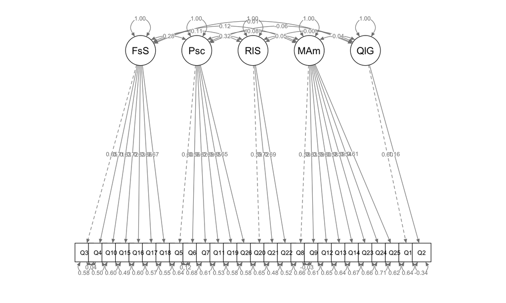

```r
# Visualização do modelo refinado
semPaths(afc_refinado, whatLabels = "std", layout = "tree",
         edge.label.cex = 0.7, normalize = FALSE)
```

# 6 Análise de Confiabilidade

```r
# Calcular o alfa de Cronbach para cada domínio
alpha_fisico <- psych::alpha(questoes[, c("Q3", "Q4", "Q10", "Q15", "Q16", "Q17", "Q18")])
alpha_psico <- psych::alpha(questoes[, c("Q5", "Q6", "Q7", "Q11", "Q19", "Q26")])
alpha_social <- psych::alpha(questoes[, c("Q20", "Q21", "Q22")])
alpha_ambiente <- psych::alpha(questoes[, c("Q8", "Q9", "Q12", "Q13", "Q14", "Q23", "Q24", "Q25")])
alpha_geral <- psych::alpha(questoes[, c("Q1", "Q2")])

# Exibir resultados
alpha_fisico$total
```

```
##  raw_alpha std.alpha   G6(smc) average_r     S/N        ase     mean        sd
##  0.8490384 0.8491611 0.8301302  0.445746 5.62959 0.01031669 3.392286 0.8520879
##   median_r
##  0.4522841
```

```r
alpha_psico$total
```

```
##  raw_alpha std.alpha   G6(smc) average_r      S/N        ase     mean        sd
##  0.8010304 0.8009165 0.7726448  0.401378 4.023019 0.01377815 3.439667 0.8126518
##   median_r
##  0.4029234
```

```r
alpha_social$total
```

```
##  raw_alpha std.alpha   G6(smc) average_r      S/N       ase     mean        sd
##  0.7072845 0.7078865 0.6197645  0.446834 2.423327 0.0227081 3.637333 0.8675511
##   median_r
##  0.4364318
```

```r
alpha_ambiente$total
```

```
##  raw_alpha std.alpha   G6(smc) average_r      S/N        ase   mean        sd
##  0.8101134 0.8100562 0.7912416 0.3477223 4.264714 0.01283664 3.3155 0.6978512
##   median_r
##  0.3565007
```

```r
alpha_geral$total
```

```
##  raw_alpha std.alpha   G6(smc) average_r      S/N        ase  mean       sd
##  0.8226244 0.8228775 0.6990585 0.6990585 4.645811 0.01584876 2.994 1.121374
##   median_r
##  0.6990585
```

# 7 Conclusão e Interpretação Clínica

Nesta seção, você deve interpretar os resultados e discutir as implicações para a compreensão da qualidade de vida em contextos de saúde.

1. Discuta como os fatores encontrados se alinham (ou não) com as dimensões teóricas do WHOQOL-BREF
2. Avalie a confiabilidade e validade da estrutura fatorial
3. Considere as limitações do estudo e sugira pesquisas futuras
4. Discuta a aplicabilidade dos resultados para profissionais de saúde

# 8 Exercícios Propostos

1. Calcule a consistência interna (alfa de Cronbach) para cada um dos fatores encontrados na AFE (não apenas para os teóricos)
2. Realize a AFE com rotação oblíqua (promax ou oblimin) e compare os resultados com a rotação varimax
3. Teste um modelo alternativo na AFC com um número diferente de fatores (por exemplo, um modelo de 3 ou 5 fatores)
4. Crie uma variável de agrupamento (por exemplo, “sexo” com valores 1 e 2) e investigue se existe invariância fatorial entre esses grupos
5. Propor e testar um modelo refinado baseado nos índices de modificação obtidos, justificando teoricamente cada modificação

# 9 Gabarito : Análise Fatorial em Dados de Saúde Mental

Este gabarito interpreta os resultados esperados da análise fatorial aplicada aos dados simulados baseados no questionário WHOQOL-BREF, um instrumento validado pela Organização Mundial da Saúde que avalia qualidade de vida.

## 9.1 1. Simulação e Exploração dos Dados

Nesta etapa, simulamos dados que refletem a estrutura teórica do WHOQOL-BREF com 26 questões distribuídas em quatro domínios principais, mais um domínio geral: - Saúde Física (7 itens): Q3, Q4, Q10, Q15, Q16, Q17, Q18 - Psicológico (6 itens): Q5, Q6, Q7, Q11, Q19, Q26 - Relações Sociais (3 itens): Q20, Q21, Q22 - Meio Ambiente (8 itens): Q8, Q9, Q12, Q13, Q14, Q23, Q24, Q25 - Qualidade de Vida Geral (2 itens): Q1, Q2

**Interpretação:** - A matriz de correlação visualizada deve mostrar blocos de correlações mais fortes entre itens do mesmo domínio, confirmando a estrutura fatorial subjacente - Também devem ser visíveis correlações cruzadas moderadas entre alguns domínios, especialmente entre o domínio físico e psicológico, simulando as complexidades reais dos dados de saúde - A escala Likert de 1-5 em todos os itens reflete a estrutura do instrumento original

## 9.2 2. Análise Fatorial Exploratória (AFE)

### 9.2.1 Adequação dos Dados

**Teste KMO (Kaiser-Meyer-Olkin):** - Valores esperados: Entre 0.7 e 0.9, indicando boa adequação dos dados simulados para análise fatorial - Interpretação: Um valor KMO elevado confirma que os padrões de correlações simulados são apropriados para a análise fatorial

**Teste de Esfericidade de Bartlett:** - Valores esperados: p < 0.001, rejeitando a hipótese nula - Interpretação: A significância do teste confirma que as correlações entre variáveis são estatisticamente significativas, permitindo prosseguir com a análise

### 9.2.2 Determinação do Número de Fatores

**Análise Paralela:** - Resultado esperado: Indicação de 4 ou 5 fatores, consistente com a estrutura simulada - Interpretação: O gráfico de scree-plot mostra que os eigenvalues reais dos primeiros 4-5 fatores estão acima dos eigenvalues aleatórios, sugerindo que devemos reter esses fatores

## 9.3 3. Análise Fatorial Confirmatória (AFC)

### 9.3.1 Definição e Ajuste do Modelo

O modelo proposto segue a estrutura teórica do WHOQOL-BREF com 5 fatores latentes (incluindo o fator de Qualidade Geral).

**Índices de ajuste esperados:** - CFI (Comparative Fit Index): > 0.90 para ajuste aceitável, > 0.95 para bom ajuste - TLI (Tucker-Lewis Index): > 0.90 para ajuste aceitável, > 0.95 para bom ajuste - RMSEA (Root Mean Square Error of Approximation): < 0.08 para ajuste aceitável, < 0.05 para bom ajuste - SRMR (Standardized Root Mean Square Residual): < 0.08 para ajuste aceitável

### 9.3.2 Índices de Modificação

**Interpretação:** - Os índices de modificação sugerem covariâncias residuais não modeladas - Modificações no modelo podem ser justificadas quando refletem sobreposições de conteúdo entre itens ou efeitos de método

## 9.4 4. Modelo Refinado

**Abordagem:** - Adicionar covariâncias entre erros residuais para itens com alto índice de modificação e justificativa teórica - Manter a estrutura principal dos cinco fatores intacta

## 9.5 5. Análise de Confiabilidade

**Interpretação:** - Valores acima de 0.7 indicam boa consistência interna - Para escalas com poucos itens (como Relações Sociais e Qualidade Geral), valores acima de 0.6 são aceitáveis

### 9.5.1 1. Consistência Interna dos Fatores da AFE

**Abordagem:** Agrupar os itens por suas cargas fatoriais mais altas na AFE (não pela estrutura teórica) e calcular o alfa para cada conjunto.

**Expectativa:** Os valores de alfa para os fatores empiricamente identificados devem ser semelhantes, ou ligeiramente, superiores aos dos fatores teóricos, já que os fatores da AFE são compostos por itens com correlações mais fortes entre si.

### 9.5.2 2. AFE com Rotação Oblíqua

**Expectativa:** - Estrutura fatorial semelhante, mas com cargas mais “limpas” (menos cargas cruzadas) - Correlações moderadas entre os fatores (0.3-0.5)

**Interpretação:** A rotação oblíqua é teoricamente mais apropriada para o WHOQOL-BREF, pois permite correlações entre os fatores. A matriz de correlação fatorial deve mostrar as relações mais fortes entre os domínios Físico e Psicológico, assim como entre Psicológico e Relações Sociais.

### 9.5.3 3. Modelo Alternativo na AFC

**Possibilidade:** Testar um modelo com 3 fatores combinando aspectos físicos e psicológicos.

**Expectativa:** O modelo de 5 fatores deve apresentar melhor ajuste aos dados do que o modelo de 3 fatores, confirmando a distinção entre os domínios.

**Interpretação:** - Comparação pelos índices AIC e BIC (valores menores indicam melhor ajuste) - Diferença nos índices de ajuste (CFI, TLI, RMSEA) - Interpretabilidade teórica dos modelos

### 9.5.4 4. Invariância Fatorial

**Abordagem:** 1. Criar uma variável de agrupamento (ex: “sexo” com valores 1 e 2 aleatoriamente designados) 2. Testar progressivamente: - Invariância configuracional (mesma estrutura) - Invariância métrica (mesmas cargas) - Invariância escalar (mesmos interceptos)

**Expectativa:** Como os dados foram simulados sem diferenças de grupo, devemos encontrar invariância em todos os níveis, com pequenas variações devidas ao acaso.

### 9.5.5 5. Modelo Refinado Justificado

**Justificativa:** Estas covariâncias refletem similaridade de conteúdo ou método de resposta. É crucial que as modificações sejam teoricamente fundamentadas, não apenas estatisticamente sugeridas.

## 9.6 Conclusão e Interpretação Clínica

1. **Saúde Física:** Aspectos relacionados à dor, energia, mobilidade e capacidade para atividades
2. **Psicológico:** Sentimentos positivos e negativos, autoestima, imagem corporal
3. **Relações Sociais:** Suporte social, relacionamentos pessoais, sexualidade
4. **Meio Ambiente:** Segurança, recursos financeiros, acesso a serviços, transporte
5. **Qualidade de Vida Geral:** Avaliação global da qualidade de vida e satisfação com a saúde

Esta estrutura fatorial proporciona aos profissionais de saúde uma avaliação multidimensional da qualidade de vida, permitindo: - Identificação de domínios específicos que precisam de intervenção - Monitoramento da eficácia de tratamentos não apenas em sintomas físicos, mas em aspectos mais amplos do bem-estar - Abordagem holística e centrada no paciente

Para aplicação clínica, é importante reconhecer que os domínios não são completamente independentes. As intervenções dirigidas a um domínio (ex: físico) podem ter impacto em outros domínios (ex: psicológico), refletindo a natureza interconectada da qualidade de vida.